# R Módulo VI: Series de Tiempo

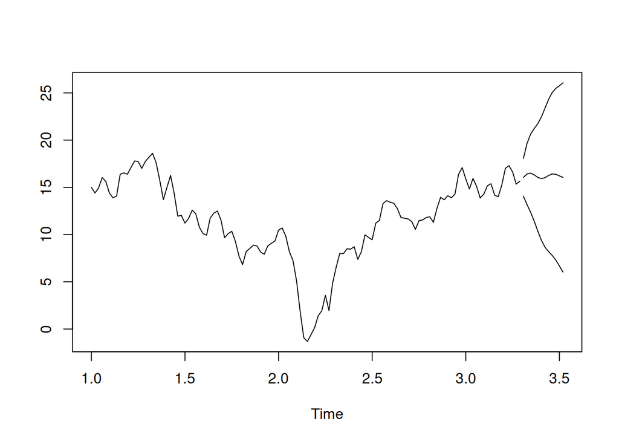

```r
ts.plot(kleenex, pron1$pred, pron1$pred +2*pron1$se, pron1$pred -2*pron1$se)
```

Ejemplo del IPC de la Bolsa Mexicana de Valores. Los datos fueron extraídos de la página del Banco de México. Son datos diarios desde enero de 1999 hasta el 23 de septiembre de 2005.

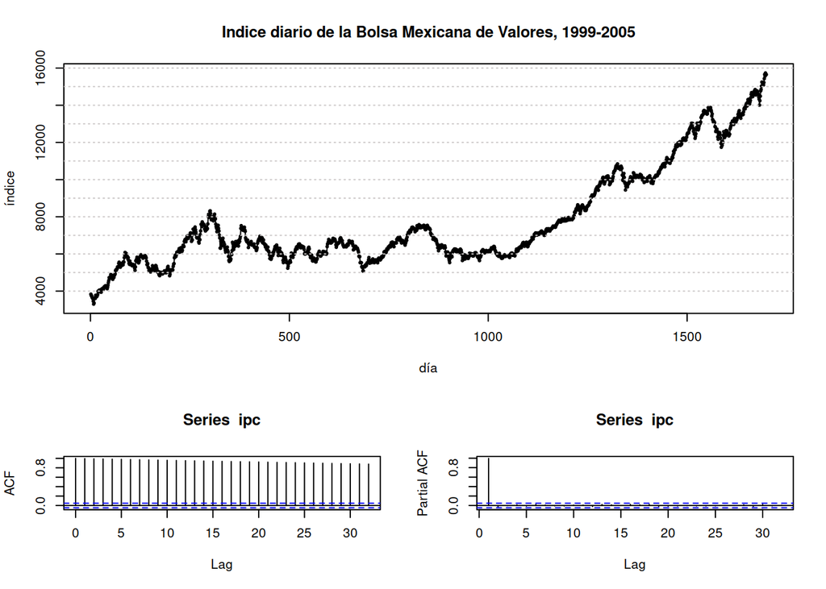

```r
ipc <- read.csv("ipcbmv1999-2005.txt", header = T)$ipc
# la función layout permite hacer arreglos de gráficas de diferentes dimensiones
# en un sólo frame.
layout(rbind(c(1,1), c(0,0), c(2,3)), heights = c(2,0,1))
plot(ipc, type = "o", cex = 0.4,
     main = "Indice diario de la Bolsa Mexicana de Valores, 1999-2005", xlab = "día", ylab = "índice")
abline(h = seq(4000, 16000, by = 1000), col = "snow3", lty=3) #agrega lineas punteadas horizontales
acf(ipc) #función de autocorrelación
pacf(ipc) #función de autocorrelación parcial
```

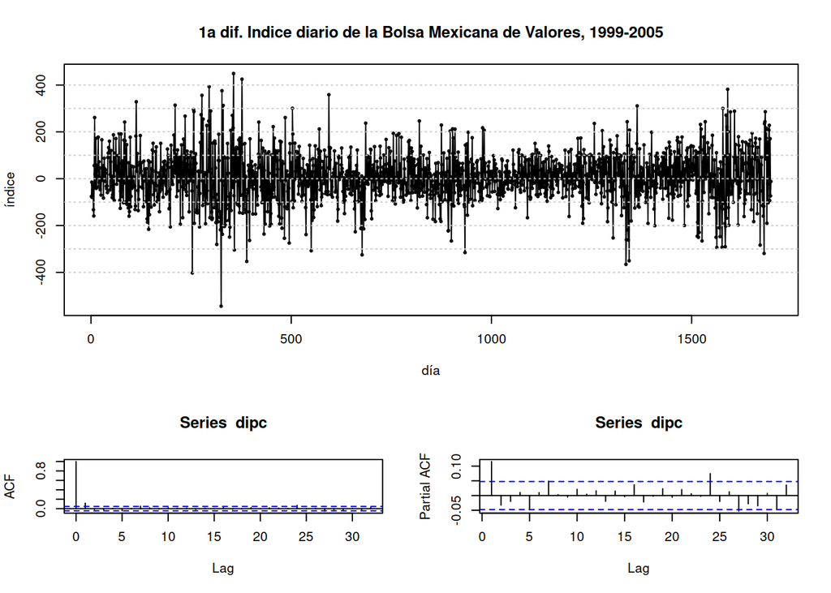

```r
# Diferenciamos la serie para tratar de hacerla estacionaria
# y reptimos las gráficas para la serie diferenciada
dipc <- diff(ipc)
layout(rbind(c(1,1),c(0,0),c(2,3)),heights=c(2,0,1))
plot(dipc,type="o",cex=0.4,
main="1a dif. Indice diario de la Bolsa Mexicana de Valores, 1999-2005",xlab="día",ylab="índice")
abline(h=seq(-400,400,by=100),col="snow3",lty=3) #agrega lineas punteadas horizontales
acf.ipcdif <- acf(dipc) #función de autocorrelación
pacf.ipcdif <- pacf(dipc) #función de autocorrelación parcial
```

Calculemos algunas estadísticas para la serie diferenciada, para verificar si es ruido blanco. Tomemos $h=30$:

```r
#Box-Pierce
Box.test(dipc,lag = 30, type = "Box-Pierce")
```

```
    Box-Pierce test

data:  dipc
X-squared = 57.41, df = 30, p-value = 0.001874
```

```r
#Ljung-Box
Box.test(dipc,lag = 30, type = "Ljung-Box")
```

```
    Box-Ljung test

data:  dipc
X-squared = 57.875, df = 30, p-value = 0.001652
```

```r
(mod1 <- arima(dipc,order = c(3,1,2))) # Ejemplo de un modelo ajustado
```

```
Call:
arima(x = dipc, order = c(3, 1, 2))

Coefficients:
         ar1      ar2      ar3      ma1     ma2
      0.3965  -0.0643  -0.0113  -1.2759  0.2780
s.e.  1.0606   0.1273   0.0441   1.0608  1.0579

sigma^2 estimated as 10691:  log likelihood = -10282.15,  aic = 20576.31
```

```r
# Prueba de Dickey Fuller para revisar si la serie es estacionaria (también se conocen como pruebas de
# raíz unitaria)
library(tseries)  # aqui está la función.
adf.test(dipc, k = 0) # k es el número de componentes incluídos en la ecuación de regresión que se prueba
```

```
    Augmented Dickey-Fuller Test

data:  dipc
Dickey-Fuller = -36.7, Lag order = 0, p-value = 0.01
alternative hypothesis: stationary
```

La prueba de Dicker-Fuller consiste en estimar la regresión:
$$\nabla y_t = \phi y_{t-1} +\beta_1\nabla y_{t-1} + \beta_2 \nabla y_{t-2} + \cdots + \beta_p \nabla y_{t-p} + u_t$$
donde $u_t$ es un componente de error que se supone tiene media 0.

## Modelos más complicados

Para el modelo ardl, se puede consultar un ejemplo en: https://rpubs.com/cyobero/ardl